# Homework 3

Elizabeth Chung, Shay Diamond, Flaka Bajraktari, Ekaterina Marbot, and Lara Adelaja

10/2/2018

## Ages by Borough from PUMS

2a. (Kate) What is the average age of people in Brooklyn? In Queens? Is there a statisitcally signficant difference?

The average age of people in Brooklyn is 37.9 and in Queens is 40.4. Taking the difference between the sample means, the point estimate for the difference betweeen the population means is

$$\left|\bar{x}_{bk} - \bar{x}_{qn}\right| =
\left|37.9 - 40.4\right| =
2.5$$

2b. (Kate) Let’s create 99% confidence intervals for each.

First, we’ll caluclate standard deviations and the number of people that live in each borough:
$$\begin{align*}
s_{bk} &= 22.99 & s_{qn} &= 22.913 \\
n_{bk} &= 24614 & n_{qn} &= 21325 \\
\end{align*}$$

99% confidence interval for the population mean, age of people in_Brooklyn:

$$E_{bk} = z_{\alpha/2} \frac{22.99}{\sqrt{24614}} = 0.38 \implies
37.52 \leq μ_{bk} \leq 38.28$$

99% confidence interval for the population mean, age of people in_Queens:
$$E_{qn} = z_{alpha/2} \frac{22.913}{\sqrt{21325}} = 0.4 \implies
40 \leq μ_{qn} \leq 40.8$$

The point estimate for the difference= 2.53925. 99% confidence interval for the difference between the population means in Queens and in_Brooklyn:
$$E = 0.5532 \\
1.9861 \leq μ_{bk} - μ_{qn} \leq 3.0924$$

2c. *Did you snip off the top-coded people? Re-do the test without those people. How does the p-value change?* If we snip off the top-coded people by using function “rm”, p-value will decrease. It happened because we reduced spread of the value.

### Normalized Ages

We normalized all of the ages to the [0,1] interval, using the below function:

```r
norm_varb <- function(v) {
    m <- min(v, na.rm = TRUE)
    M <- max(v, na.rm = TRUE)
    (v - m)/abs(M - m)
}
```

To test if there is a statistically significant difference, we set up the following hypothesis test:
$$H_0:\ μ_{bk} - μ_{qn} \ = \ 0 \\
H_a:\ μ_{bk} - μ_{qn} \ \neq \ 0$$

Then determined our test statistic with a confidence level of 99%:

```r
bk_var <- var(bk_norm_age)
qn_var <- var(qn_norm_age)

bk_n <- length(bk_norm_age)
qn_n <- length(qn_norm_age)

our_df <- min(bk_n, qn_n) - 1

numerator <- bk_xbar - qn_xbar
denominator <- sqrt(bk_var/bk_n + qn_var/qn_n)

test_stat <- numerator/denominator

# our t-value
t.value <- pt(test_stat, our_df)
# [1] 1.777656e-32

# t-alpha
t.alpha <- qt(0.005, our_df)
# [1] -2.57606
```

Since our t-value is (significantly) less than the absolute value of t-alpha for our test, then we can reject the null hypothesis and say that it is statistically significant.

Now, to change our evaluation, we will eliminate the observations with top-coded ages.

```r
bk_norm_age <- norm_varb(Age[in_Brooklyn == 1 & Age < 90])
qn_norm_age <- norm_varb(Age[in_Queens == 1 & Age < 90])

bk_xbar <- mean(bk_norm_age)
qn_xbar <- mean(qn_norm_age)

bk_var <- var(bk_norm_age)
qn_var <- var(qn_norm_age)

bk_n <- length(bk_norm_age)
qn_n <- length(qn_norm_age)

our_df <- min(bk_n, qn_n) - 1

numerator <- bk_xbar - qn_xbar
denominator <- sqrt(bk_var/bk_n + qn_var/qn_n)

test_stat <- numerator/denominator

#our t-value
t.val <- pt(test_stat, our_df)
t.val
#t-alpha
t.alpha <- qt(0.005, our_df)
t.alpha
```

[output not shown]

2e. Based on our knowledge of those boroughs, these results are not surprising as typically more young adults and families with several children live in Brooklyn than in Queens due to the religious populations that have larger families and the “hipster” vibe in Brooklyn compared to Queens.

We can test this by breaking out the differences using the particular age ranges of those under 18 (“children”) and those 65 and older (“old”) by conducting a hypothesis test for each category comapring the proportions of the population:

$$H_0:\ p_1 - p_2 \ = \ 0 \\
H_a:\ p_1 - p_2 \ \neq \ 0$$

First, we compare the children.

```r
bk_children <- Age[in_Brooklyn == 1 & Age < 18]
qn_children <- Age[in_Queens == 1 & Age < 18]

bk_children_n <- length(bk_children)
qn_children_n <- length(qn_children)

p1_children <- mean(bk_children)
p2_children <- mean(qn_children)

numerator_pchild <- bk_children_n + qn_children_n
denominator_pchild <- length(Age[in_Brooklyn == 1]) + length(Age[in_Queens == 1])
pbar_children <- numerator_pchild/denominator_pchild

numerator1 <- p1_children - p2_children
denominator1 <- sqrt(pbar_children * (1 - pbar_children)
   * ((1 / bk_children_n) + (1 / qn_children_n)))

z_value1 <- numerator1/denominator1
pnorm(z_value1)
```

```
## [1] 7.954274e-234
```

Since this p-value is significantly smaller than our alpha when the confidence level is still at 99%, so we reject the null hypothesis that the proportions of children in Brooklyn and Queens are the same.

When running the same calculations for the “old” category under the same population proportion hypothesis test, we get the following z and p values:

```r
bk_old <- Age[in_Brooklyn == 1 & Age > 64]
qn_old <- Age[in_Queens == 1 & Age > 64]

bk_old_n <- length(bk_old)
qn_old_n <- length(qn_old)

p1_old <- mean(bk_old)
p2_old <- mean(qn_old)

numerator_pold <- bk_old_n + qn_old_n
denominator_pold <- length(Age[in_Brooklyn == 1]) + length(Age[in_Queens == 1])
pbar_old <- numerator_pold/denominator_pold

numerator2 <- p1_old - p2_old
denominator2 <- sqrt(pbar_old * (1 - pbar_old)
                     * ((1 / bk_old_n) + (1 / qn_old_n)))

z_value2 <- numerator2/denominator2
pnorm(z_value2)
```

```
## [1] 0.1282153
```

Once this is completed for each borough, we then create a matrix to hold all the data of the proportions of age by borough and use it to make a stacked bar plot:

[figure not shown]

Another type of bar graph that could also compare these proportions is a side-by-side bar chart where the proportions are next to eachother instead of stacked, however due to the 5 boroughs and 6 different age categories, this may become cumbersome and hard to read, so a stacked bar chart would be easiest to compare.

## Commute and wage data

I used the PUMS data to look at wages and commute type, getting this table for people in the City: (you can answer parts a-c without R)

| w | bus | car | subway |
| --- | --- | --- | --- |
| Wage below $25,000 | 1501 | 2394 | 3704 |
| Wage above $75,000 | 385 | 1825 | 2194 |

### Commute method conditioned on wages

1. Given that someone takes the bus to work, what is the probability that they’re making wages above $75,000? Answer: $\frac{385}{1501+385}=0.2$
2. Given that someone takes the subway to work, what is the probability that they make wages below $25,000? Answer: $\frac{3704}{3704+2194}=0.63$
3. Given that someone has wage above $75,000, what is the probability that they drive a car to work? Answer: $\frac{1825}{385+1825+2194}=0.41$

### The socioeconomics of transportation by borough

Using the PUMS data, can you narrow this further - what are the socioeconomics of bus/subway in the various boroughs? What is the wealthiest PUMA area and how do the people living there tend to commute? Can you find interesting patterns?

This is a very broad question. First, we’ll factor boroughs and commute methods and add neighborhood names to the PUMA values. We’ll also select only the columns we need which are commute, borough, PUMA, income_total. We also omit any observations with NA values.

Next, we’ll look at the breakdown of commutes by borough and income bracket. The data given to us used wages, but we’re going to use income_total.

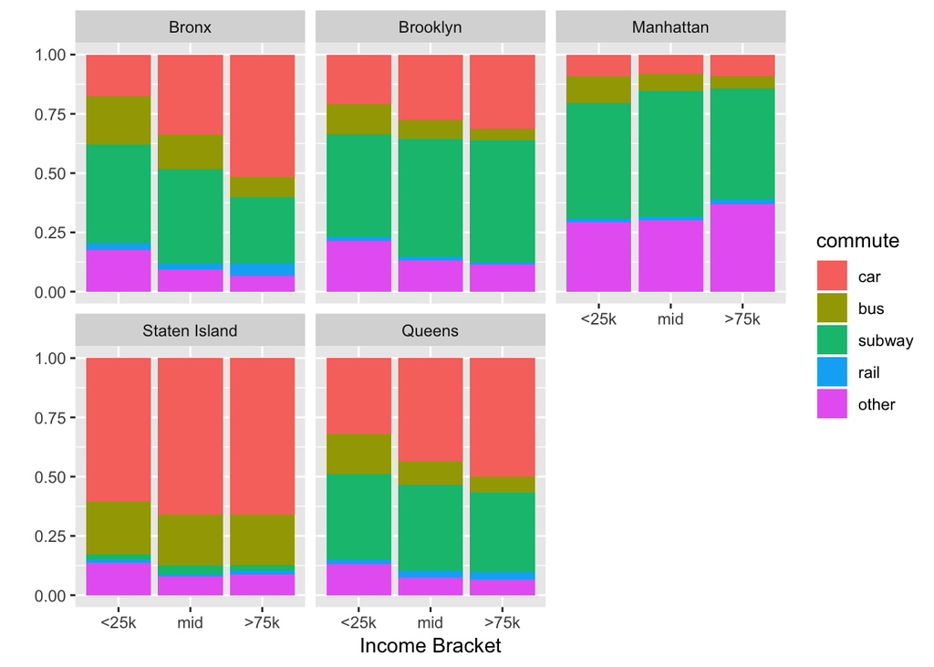

My biggest take away from these graphs is that more income means you are more likely to use a car for your commute. This difference is more obvious in the outer boroughs. The Bronx and Queens seem to have the biggest disparities between the lowest bracket and the highest. I’m very curious what falls into “other” considering there is such a large portion in Manhattan. Are those bikers? Walkers? Scooter…ers…? The fact that staten island has so few people that commute by subway and so many that use cars it makes me wonder if most people in Staten Island either work in Jersey or stay in Staten Island.

### How the rich and fabulous commute

Below are the neighborhoods with the highest mean total_income with percentages of each mode of transportation. The fact that the Upper West Side is so wealthy and so reliant on the subway props up one of my long held suspicions that the 1-2-3 line is the most reliable line in the city. I would like to do further research, of course.

```
## # A tibble: 5 x 8
##   PUMA             p.car   p.bus p.subway p.rail p.other mean.income     n
##   <fct>            <dbl>   <dbl>    <dbl>  <dbl>   <dbl>       <dbl> <int>
## 1 Upper East Side 0.0976 0.0854     0.453 0.0122   0.352     145200.   492
## 2 Upper West Sid… 0.0662 0.0638     0.600 0.0236   0.246     136776.   423
## 3 Chelsea, Clint… 0.0527 0.0469     0.379 0.0312   0.490     136611.   512
## 4 Battery Park C… 0.0678 0.00565    0.556 0.0132   0.358     135542.   531
## 5 Murray Hill, G… 0.0765 0.0792     0.293 0.0211   0.530     122762.   379
```

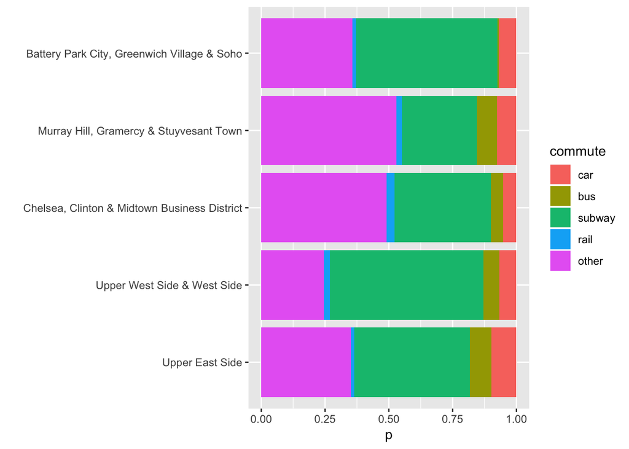

### kNN test to predict transportation method

Try the machine learning K-nearest-neighbor algorithm on the PUMS data to get another view of the commuting pattern from above. How good of a classification of commute type can you get? Explain what you believe are important variables in this classification. You might explore the “caret” function.

```r
# Clean the data, add columns where necessary (especially to factor), filter, and pull columns
pums.compact <- dat_pums_NY %>%
  filter(in_NYC == 1,
#         Commute_rail == 0,
#         Commute_other == 0,
         Age >= 18,
         Age < 66) %>%
  mutate(income_total = norm_varb(income_total),
         borough = factor(in_Bronx +
             2 * in_Brooklyn +
             3 * in_Manhattan +
             4 * in_StatenI +
             5 * in_Queens,
           levels = 1:5,
           labels = c("Bronx",
                      "Brooklyn",
                      "Manhattan",
                      "Staten Island",
                      "Queens")
         ),
         commute = factor(Commute_car +
             Commute_bus * 2 +
             Commute_subway * 3 +
             Commute_rail * 4 +
             Commute_other * 5,
           levels = c(1, 2, 3, 4, 5),
           labels = c(
             "Commute_car",
             "Commute_bus",
             "Commute_subway",
             "Commute_rail",
             "Commute_other" )
         )
         ) %>%
  select(commute,
         in_Bronx,
         in_Brooklyn,
         in_Manhattan,
         in_Queens,
         in_StatenI,
         income_total
#         female
#         immig,
#         work_fullyr
          )

good.pums.obs <- complete.cases(pums.compact)
pums.compact  <- subset(pums.compact, good.pums.obs)
y.data <- pums.compact

set.seed(12345)
NN_obs <- sum(good.pums.obs)
train.obs <- (runif(NN_obs) < 0.8)

train.data <- subset(pums.compact, train.obs)
test.data  <- subset(pums.compact, !train.obs)
cl.data    <- y.data$commute[train.obs]
true.data  <- y.data$commute[!train.obs]

summary(cl.data)
```

```
##    Commute_car    Commute_bus Commute_subway   Commute_rail  Commute_other
##           7049           2623           9395            472           3592
```

```r
predicted.commute <- knn(train = train.data[-1],
                         test = test.data[-1],
                         cl = cl.data,
                         k = 9)
n.correctly.predicted <- sum(predicted.commute == true.data)
correct.rate <- n.correctly.predicted / length(predicted.commute)
print(correct.rate)
```

```
## [1] 0.4480681
```